# Assignment: Milestone Report

## Introduction

The goal of this project is just to display that you’ve gotten used to working with the data and that you are on track to create your prediction algorithm. Please submit a report on R Pubs (http://rpubs.com/) that explains your exploratory analysis and your goals for the eventual app and algorithm. This document should be concise and explain only the major features of the data you have identified and briefly summarize your plans for creating the prediction algorithm and Shiny app in a way that would be understandable to a non-data scientist manager. You should make use of tables and plots to illustrate important summaries of the data set. The motivation for this project is to: 1. Demonstrate that you’ve downloaded the data and have successfully loaded it in.2. Create a basic report of summary statistics about the data sets.3. Report any interesting findings that you amassed so far.4. Get feedback on your plans for creating a prediction algorithm and Shiny app.

## Basic report of summary statistics

```r
file_summary<-function(filepath,lines)
{
file_size=file.info(filepath)[1]/1024^2
line_count= length(lines)
words_count=sum(sapply(strsplit(lines,split = "\\s+"), length))

return(c(filepath,file_size,line_count,words_count))
}

blog_summary=file_summary("final/en_US/en_US.blogs.txt",blogs_lines)
news_summary=file_summary("final/en_US/en_US.news.txt",news_lines)
twitter_summary=file_summary("final/en_US/en_US.twitter.txt",twitter_lines)


sumarrydata= matrix(data =c(blog_summary,news_summary,twitter_summary),nrow = 3,ncol = 4,byrow = TRUE )
colnames(sumarrydata)=c("File","File size(MB)","Lines_Count","Words_count")
sumarrydata
```

```
##      File                            File size(MB) Lines_Count Words_count
## [1,] "final/en_US/en_US.blogs.txt"   200.4242      899288      37334441
## [2,] "final/en_US/en_US.news.txt"    196.2775      77259       2643972
## [3,] "final/en_US/en_US.twitter.txt" 159.3641      2360148     30373792
```

## Exploratory Data Analysis

Creating Corpus and Cleaning the text file

```r
#Loading "tm" package for NLP
#install.packages("tm")
library(tm)
#install.packages("SnowballC")
library(SnowballC)

  clean_text<- function(sampletext){

    vs<-VectorSource(sampletext)
    corpus=VCorpus(vs,readerControl = list(readPlain,language="en",load=TRUE))

    corpus=tm_map(corpus,content_transformer(tolower))
    corpus= tm_map(corpus,removeNumbers)
    corpus= tm_map(corpus,removePunctuation)
    corpus= tm_map(corpus,removeWords,stopwords("english"))
    corpus= tm_map(corpus,stemDocument)
    corpus= tm_map(corpus,stripWhitespace)
    return(corpus)
  }
```

Common data cleaning tasks associated with text mining are:

1.Converting the entire document to lower case 2.Removing punctuation marks (periods, commas, hyphens etc) 3.Removing stopwords (extremely common words such as “and”, “or”, “not”, “in”, “is” etc) 4.Removing numbers 5.Filtering out unwanted terms 6.Removing extra whitespace

## High Frequency words

Finding out the most freqest used Words.

```r
high_freq_words<-function(corpus){
dtm=DocumentTermMatrix(corpus)
dtmmatrix=as.matrix(dtm)
freq_words=colSums(dtmmatrix)
freq_word=as.data.frame(sort(freq_words,decreasing = TRUE))
freq_word$words=row.names(freq_word)
colnames(freq_word)<-c("Frequency","Words")

return(freq_word)
}
```

## Blogs- Bar Chart of High frequency words

Below Bar chart represents the most frequent words used in Blogs.

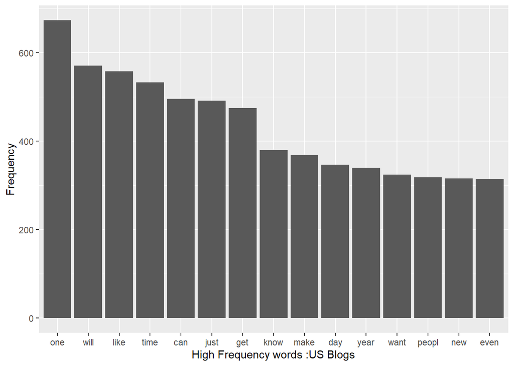

```r
#Creating Sample from Blogs.
sampletext<-sample(blogs_lines,size=length(blogs_lines)*.005,replace=FALSE)
clean_blogs= clean_text(sampletext)
hf_words=high_freq_words(clean_blogs)
hfw_blogs=head(hf_words,15)

library(ggplot2)
p<-ggplot()+geom_bar(data = hfw_blogs,aes(x=reorder(Words,-Frequency),y = Frequency),stat = "identity")

  p+xlab("High Frequency words :US Blogs")+ylab("Frequency")
```

## News- Bar Chart of High frequency words

Below Bar chart represents the most frequent words used in News

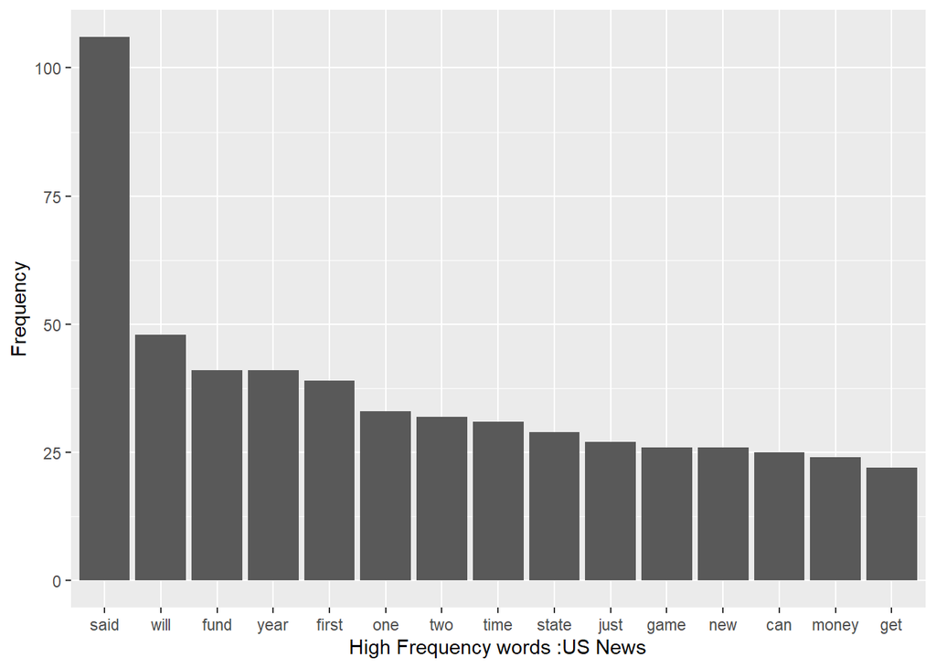

```r
sampletext<-sample(news_lines,size=length(news_lines)*.005,replace=FALSE)
clean_news= clean_text(sampletext)
hf_words=high_freq_words(clean_news)
hfw_news=head(hf_words,15)


p<-ggplot()+geom_bar(data = hfw_news,aes(x=reorder(Words,-Frequency),y = Frequency),stat = "identity")

  p+xlab("High Frequency words :US News")+ylab("Frequency")
```

## Twitter- Bar Chart of High frequency words

Below Bar chart represents the most frequent words used in Twitter.

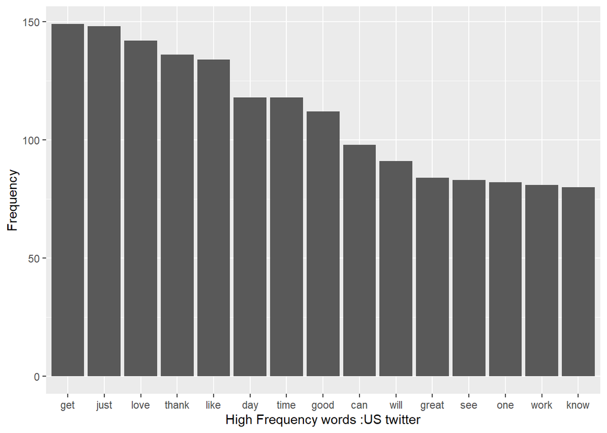

```r
sampletext<-sample(twitter_lines,size=length(twitter_lines)*.001,replace=FALSE)
clean_twitter= clean_text(sampletext)
hf_words=high_freq_words(clean_twitter)
hfw_twitter=head(hf_words,15)


p<-ggplot()+geom_bar(data = hfw_twitter,aes(x=reorder(Words,-Frequency),y = Frequency),stat = "identity")

  p+xlab("High Frequency words :US twitter")+ylab("Frequency")
```

```r
#Installing "ngram" package
#install.packages("rJava")
library(rJava)
library(RWeka)


unigram<-function(mycorpus){

tok1 <- function(x) NGramTokenizer(x, Weka_control(min=1, max=1))
tdm1 <- TermDocumentMatrix(mycorpus,control = list(tokenize = tok1))
termFreq1 <- rowSums(as.matrix(tdm1))

head(sort(termFreq1,decreasing = TRUE),20)

}

bigram<-function(mycorpus){

tok2 <- function(y) NGramTokenizer(y, Weka_control(min=2, max=2))
tdm2 <- TermDocumentMatrix(mycorpus,control = list(tokenize = tok2))
termFreq2 <- rowSums(as.matrix(tdm2))
head(sort(termFreq2,decreasing = TRUE),20)
}

trigram<-function(mycorpus){
tok3 <- function(z) NGramTokenizer(z, Weka_control(min=3, max=3))
tdm3 <- TermDocumentMatrix(mycorpus,control = list(tokenize = tok3))
termFreq3 <- rowSums(as.matrix(tdm3))
head(sort(termFreq3,decreasing = TRUE),20)
}
```

```r
sampletext<-sample(blogs_lines,size=length(blogs_lines)*.001,replace=FALSE)
corpus_blogs= clean_text(sampletext)
# 20 top US blogs Unigram words
unigram(corpus_blogs)
```

```
##   one  time  will   get  like  just   can  make   use  love   day  know
##   135   104   101    97    96    92    90    79    71    70    67    65
## peopl   see first   say   new  work  year think
##    64    64    63    60    58    57    57    56
```

```r
# 20 top US blogs Bigram words
bigram(corpus_blogs)
```

```
##          right now        even though          feel like
##                 10                  8                  8
##            can get          look like              im go
##                  7                  7                  6
##          dont know         first time          hard time
##                  5                  5                  5
##          ice cream          just like         last night
##                  5                  5                  5
##         number two           year ago christian endeavor
##                  5                  5                  4
##        everyth els          felt like          first day
##                  4                  4                  4
##         flower use           just one
##                  4                  4
```

```r
# 20 top US blogs Trigram words
trigram(corpus_blogs)
```

```
##         flower use circl          peopl die polic           â\200œ peopl need
##                        4                        3                        2
##        beer regular beer           blew mind away christian endeavor supra
##                        2                        2                        2
## clark christian endeavor      coastal state state       colorado spring co
##                        2                        2                        2
##        die polic custodi             dr john sing         endeavor supra p
##                        2                        2                        2
##           look tast like      provid player point       realli realli love
##                        2                        2                        2
##       regular beer choic             sc open loop           someth like go
##                        2                        2                        2
##           tast like beer          there time zoom
##                        2                        2
```

```r
sampletext<-sample(news_lines,size=length(news_lines)*.001,replace=FALSE)
corpus_news= clean_text(sampletext)
# 20 top US News Unigram words
unigram(corpus_news)
```

```
##   said   will school recent    say   year    â\200”    â\200œ   citi    day
##     11     11     10      7      7      7      6      6      6      6
##   just    one  state   also    can casino   even    job   like   make
##      6      6      6      5      5      5      5      5      5      5
```

```r
# 20 top US News Bigram words
bigram(corpus_news)
```

```
##         new york african american      atlant citi        buy magic
##                4                2                2                2
##    general manag       last month    san francisco    social worker
##                2                2                2                2
##        tabl game         â– knopf           ã¸ job        ã¸ midcap
##                2                1                1                1
##   ã¸phoenix took     ã¸someon saw      â\200\230 anybodi        â\200\230 didnt
##                1                1                1                1
##        â\200“ great    â\200“ necessari      â\200” assembl         â\200” caus
##                1                1                1                1
```

```r
# 20 top US News Trigram words
trigram(corpus_news)
```

```
##           â– knopf page           ã¸ job hunter          ã¸ midcap also
##                       1                       1                       1
##     ã¸phoenix took lead        ã¸someon saw man        â\200\230 anybodi know
##                       1                       1                       1
##          â\200\230 didnt know     â\200“ great disrepair  â\200“ necessari unfortun
##                       1                       1                       1
##    â\200” assembl committe          â\200” caus natur      â\200” daley consolid
##                       1                       1                       1
##        â\200” first custom     â\200” increas decreas          â\200” wrote last
##                       1                       1                       1
##       â\200œ current state      â\200œ famili roomâ\200\235        â\200œ plant safeti
##                       1                       1                       1
##          â\200œ search way           â\200œ team high
##                       1                       1
```

```r
sampletext<-sample(twitter_lines,size=length(twitter_lines)*.001,replace=FALSE)
corpus_twitter= clean_text(sampletext)
# 20 top US Twitter Unigram words
unigram(corpus_twitter)
```

```
##  just   get  like thank  love  good   day  will  dont   one  know   new
##   172   150   134   133   127   117   105    99    97    89    88    88
## today   can   now   see think  look  time  make
##    83    82    79    76    74    73    71    70
```

```r
# 20 top US Twitter Bigram words
bigram(corpus_twitter)
```

```
##      right now      feel like      good morn      cant wait happi birthday
##             21             14             14             13             12
##       let know   look forward     last night    follow back       just got
##             11             11             10              9              8
##      just want      look like       dont get      dont know       new year
##              8              8              7              7              7
##   thank follow       think im      dont want      good luck        im sure
##              7              7              6              6              6
```

```r
# 20 top US Twitter Trigram words
trigram(corpus_twitter)
```

```
##       cant wait see      happi new year      boom boom boom
##                   5                   5                   4
##         let us know       ive ever seen      thing ive ever
##                   4                   3                   3
##   book feminist art    collect open new command normal mode
##                   2                   2                   2
##    cutest thing ive      dont even know       dont wanna go
##                   2                   2                   2
##   follow back pleas      good right now       hope see soon
##                   2                   2                   2
##      just keep swim       just let know      know much hate
##                   2                   2                   2
##      left wide open      let know anyth
##                   2                   2
```